# Tracking the Intangible: Quantifying Effort in the NFL

Emily Shteynberg, Luke Snavely, Sheryl Solorzano  
Advisor: Sam Ventura, Buffalo Sabres

October 25, 2025

## What Does It Mean To Give 100%?

[figure not shown]

## Background

- Effort is intangible and subjective
- Currently no objective measure of effort exists in the NFL
- Idea: previous research has explored professional soccer players reaching theoretical max acceleration capacity<sup>1</sup>
- Goals:
  - Improve estimation of individual acceleration-speed (A-S) profiles using statistical models
  - Assess how frequently players operate near or exceed their physical limits as a **proxy for effort**
[^1]: Morin, J., Mat, Y. L., Osgnach, C., Barnabò, A., Pilati, A., Samozino, P., & Di Prampero, P. E. (2021). Individual acceleration-speed profile in-situ: A proof of concept in professional football players. Journal of Biomechanics, 123, 110524. https://doi.org/10.1016/j.jbiomech.2021.110524

## Data: 2022 NFL Season<sup>1</sup>

- Game, play, player data from Weeks 1-9: 136 games
- Player tracking data: each observation is a frame in 10 fps
- Pre-processing:
  - Filtered to running plays where a running back (RB) is the ball carrier
  - Trimmed each play to frames between handoff and end of play
  - Derived directional acceleration

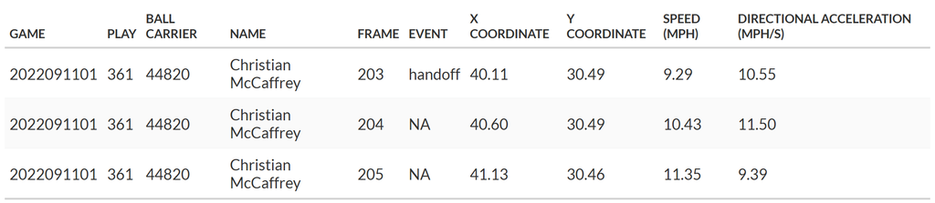

[^2]: Courtesy of NFL Big Data Bowl 2025

## Motivation: Estimate Each RB’s Theoretical Max Acceleration Frontier (Morin et al., 2021)

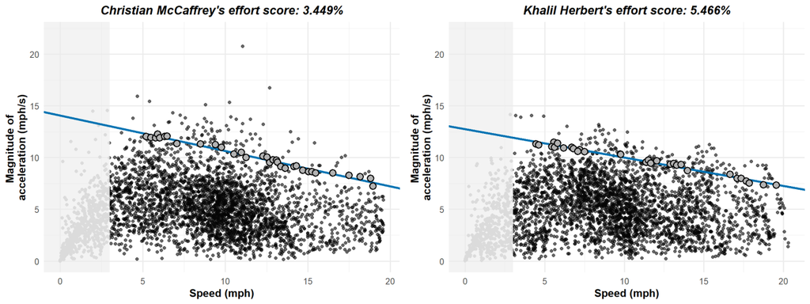

- **Effort** = % of a player’s points (frames) close to and above the regression line

## But This Approach Has Limitations

- Gives no credit to low speed points
- Unrealistic theoretical max speeds - not comparable to soccer
- Penalizes players for being athletic
- Does not differentiate between acceleration and deceleration
- Sensitive to short-term fluctuations
  - Need to smooth out noise: take 5-frame rolling mean of speed and directional acceleration

## Effort Metric #1: Quadratic Quantile Regression

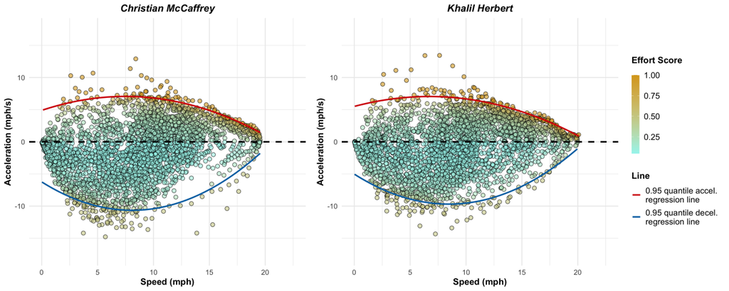

- **Effort Metric #1:**
  - Christian McCaffrey: 19.84%
  - Khalil Herbert: 21.99%

## Effort Metric #2: Quantile Generalized Additive Model (QGAM)

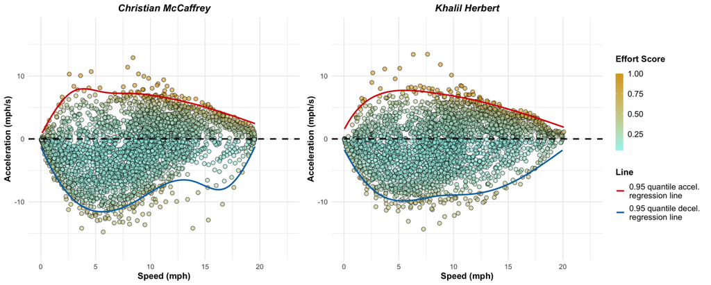

- **Effort Metric #2:**
  - Christian McCaffrey: 19.68%
  - Khalil Herbert: 20.94%

## Computing Effort

**Average frame-level effort for each player**

$$\text{Effort}_i = \begin{cases}
\frac{1}{1+d_i} & a_i\geq 0 \\
\frac{1}{2}\cdot\frac{1}{1+d_i} & a_i<0
\end{cases} \quad \implies \quad \text{Average Effort} = \frac{\sum_{i=1}^n \text{Effort}_i}{n}$$

- $d_i$ = vertical distance from point $i$ to its respective 0.95 quantile line (positive vs. negative acceleration)
  - Points surpassing their respective 0.95 quantile line are assigned a distance of 0
- $a_i$ = directional acceleration
  - Penalize points with negative acceleration by $1/2$ (deceleration is not as effortful<sup>1</sup>)
- Compute average frame-level scores to obtain the percentage of effortful frames
[^3]: Hader, K., Mendez-Villanueva, A., Palazzi, D., Ahmaidi, S., & Buchheit, M. (2016). Metabolic Power Requirement of Change of Direction Speed in Young Soccer Players: Not All Is What It Seems. PloS one, 11(3), e0149839. https://doi.org/10.1371/journal.pone.0149839

## Back-up RBs Lead Rankings

[figure not shown]

[figure not shown]

## Mix of RBs Towards Bottom

[figure not shown]

[figure not shown]

## Effort Metrics Do Not Show a Strong Correlation with Play Outcomes

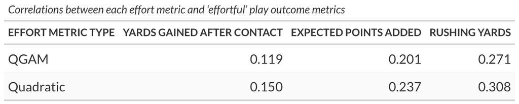

- **Conclusion**: By our definition, effort may not explain favorable play outcomes
  - Individual effort may only benefit a team to an extent
  - Football is context-dependent and a team sport

## Shifting Gears: Wide Receivers (WRs)

- RBs typically give their full effort on every single play running the ball
  - In what scenarios might offensive players not exhibit maximal effort?
- Leads us to wide receivers: do they give the same effort when they are targeted vs. when they are not?

## WRs: Data

- Pre-processing:
  - Filter to frames of receivers running their routes
  - Filter to frames between snap and arrival of pass to intended receiver
  - Same as for RBs: speed and directional acceleration calculations with 5-frame rolling mean

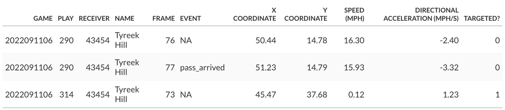

## WRs Effort Metric: QGAM Approach

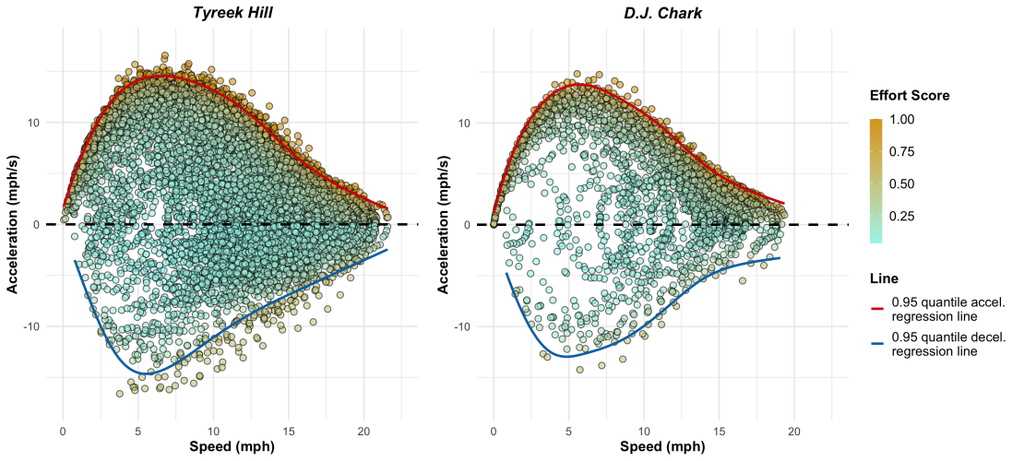

- **Hill:**
  - Overall Effort Score: 25.10%
  - Targeted Score: 26.13%
  - Not Targeted Score: 24.43%
- **Chark:**
  - Overall Effort Score: 31.83%
  - Targeted Score: 35.55%
  - Not Targeted Score: 30.96%

[figure not shown]

[figure not shown]

## Hill Shows Low Effort when Not Targeted

[figure not shown]

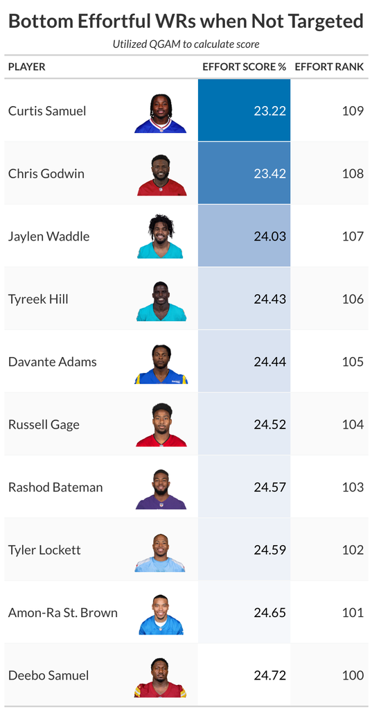

## No Extreme Change in Play-Level Effort when Targeted vs. Not Targeted

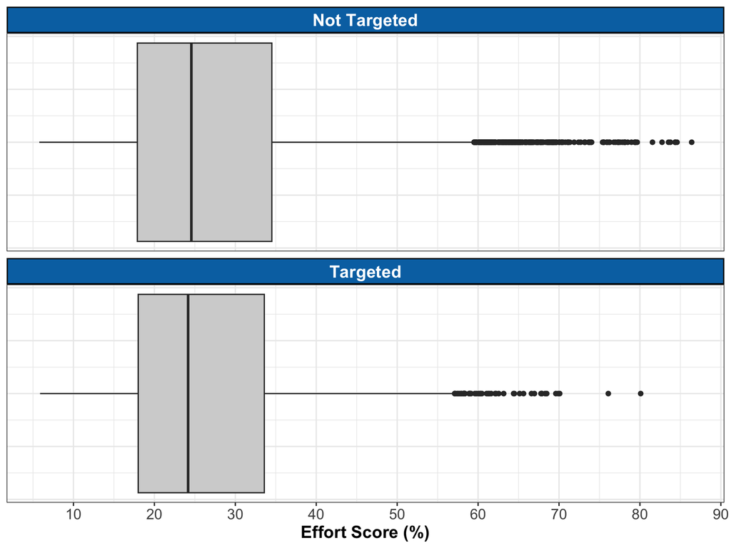

## Discussion

- Conclusions
  - Metric quantifies how often a player comes to his acceleration frontier
  - A-S-based effort alone does not explain performance
  - No extreme difference in play-level effort when targeted vs. not targeted
- Limitations
  - Metric does not fully account for game context
  - Personalized A-S curves make cross-player comparison difficult
- Future work
  - Better distinguish between high effort points
  - Find another way to validate effort metrics

# Appendix

## RB Effort Metrics are Positively Correlated

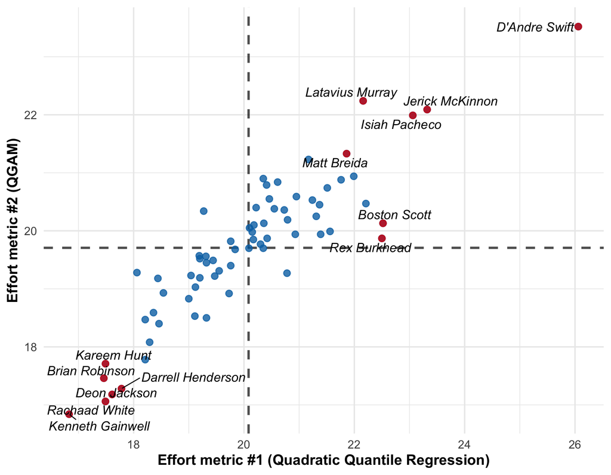

[figure not shown]

[figure not shown]

[figure not shown]

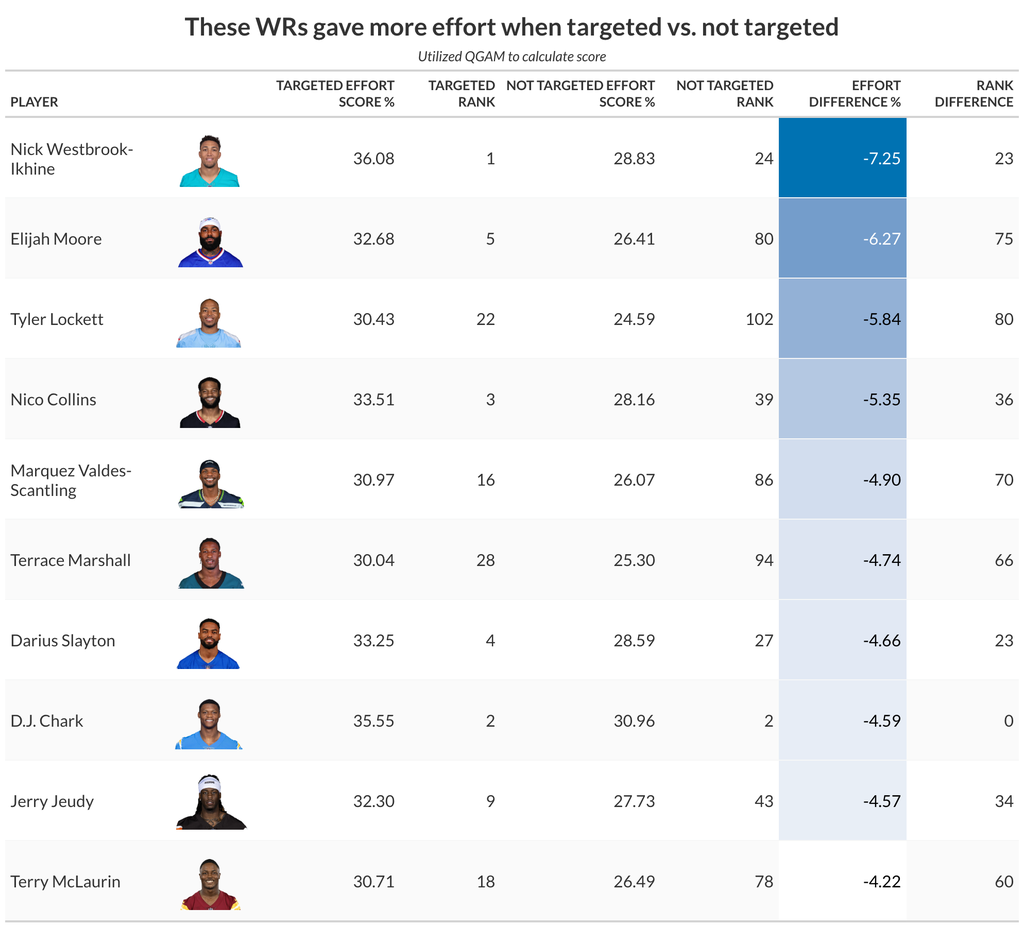

## High Effortful Targeted Plays Correlate Positively with Pass Length

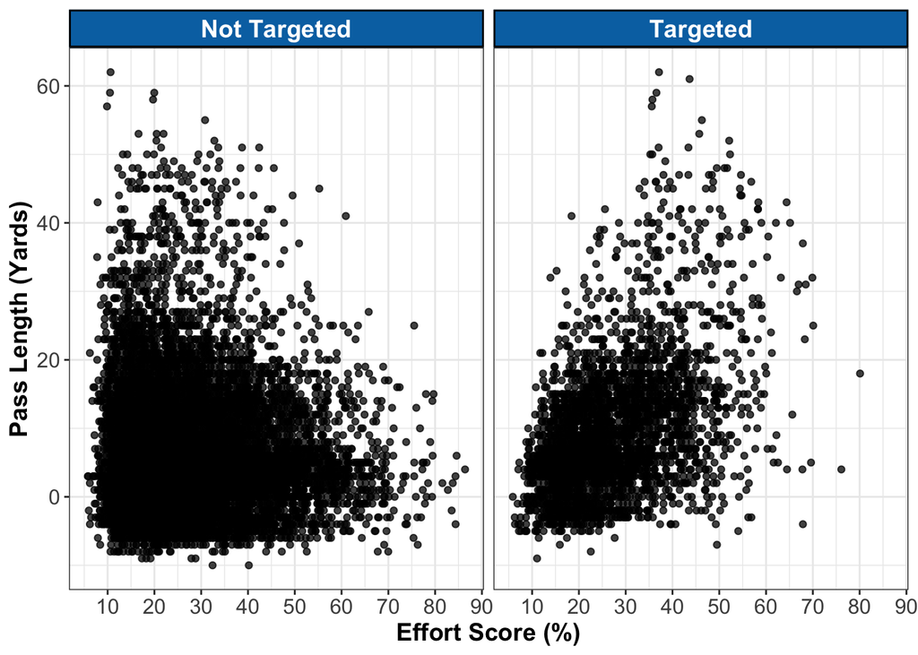